# Data Science Lecture 2, Exercise A

First, load ggplot2 to make pretty graphs. Corrplot used later in exercise.

```r
library(ggplot2)
```

We will work with mtcars dataset, so what does it look like?

```r
head(mtcars)
```

|  | mpg | cyl | disp | hp | drat | wt | qsec | vs | am | gear | carb |
| --- | --- | --- | --- | --- | --- | --- | --- | --- | --- | --- | --- |
| Mazda RX4 | 21.0 | 6 | 160 | 110 | 3.90 | 2.620 | 16.46 | 0 | 1 | 4 | 4 |
| Mazda RX4 Wag | 21.0 | 6 | 160 | 110 | 3.90 | 2.875 | 17.02 | 0 | 1 | 4 | 4 |
| Datsun 710 | 22.8 | 4 | 108 | 93 | 3.85 | 2.320 | 18.61 | 1 | 1 | 4 | 1 |
| Hornet 4 Drive | 21.4 | 6 | 258 | 110 | 3.08 | 3.215 | 19.44 | 1 | 0 | 3 | 1 |
| Hornet Sportabout | 18.7 | 8 | 360 | 175 | 3.15 | 3.440 | 17.02 | 0 | 0 | 3 | 2 |
| Valiant | 18.1 | 6 | 225 | 105 | 2.76 | 3.460 | 20.22 | 1 | 0 | 3 | 1 |

```r
tail(mtcars)
```

|  | mpg | cyl | disp | hp | drat | wt | qsec | vs | am | gear | carb |
| --- | --- | --- | --- | --- | --- | --- | --- | --- | --- | --- | --- |
| Porsche 914-2 | 26.0 | 4 | 120.3 | 91 | 4.43 | 2.140 | 16.7 | 0 | 1 | 5 | 2 |
| Lotus Europa | 30.4 | 4 | 95.1 | 113 | 3.77 | 1.513 | 16.9 | 1 | 1 | 5 | 2 |
| Ford Pantera L | 15.8 | 8 | 351.0 | 264 | 4.22 | 3.170 | 14.5 | 0 | 1 | 5 | 4 |
| Ferrari Dino | 19.7 | 6 | 145.0 | 175 | 3.62 | 2.770 | 15.5 | 0 | 1 | 5 | 6 |
| Maserati Bora | 15.0 | 8 | 301.0 | 335 | 3.54 | 3.570 | 14.6 | 0 | 1 | 5 | 8 |
| Volvo 142E | 21.4 | 4 | 121.0 | 109 | 4.11 | 2.780 | 18.6 | 1 | 1 | 4 | 2 |

Let’s get our first insights into the dataset

```r
str(mtcars)
```

```
'data.frame':   32 obs. of  11 variables:
 $ mpg : num  21 21 22.8 21.4 18.7 18.1 14.3 24.4 22.8 19.2 ...
 $ cyl : num  6 6 4 6 8 6 8 4 4 6 ...
 $ disp: num  160 160 108 258 360 ...
 $ hp  : num  110 110 93 110 175 105 245 62 95 123 ...
 $ drat: num  3.9 3.9 3.85 3.08 3.15 2.76 3.21 3.69 3.92 3.92 ...
 $ wt  : num  2.62 2.88 2.32 3.21 3.44 ...
 $ qsec: num  16.5 17 18.6 19.4 17 ...
 $ vs  : num  0 0 1 1 0 1 0 1 1 1 ...
 $ am  : num  1 1 1 0 0 0 0 0 0 0 ...
 $ gear: num  4 4 4 3 3 3 3 4 4 4 ...
 $ carb: num  4 4 1 1 2 1 4 2 2 4 ...
```

Compute the mean, median, and mode of column wt

```r
mean(mtcars$wt)
```

```
[1] 3.21725
```

```r
median(mtcars$wt)
```

[output not shown]

For mode, there is no built-in mode function! Create a variable for a table, then see what the one used the most is.

```r
y <- table(mtcars$wt)
y
names(y)[which(y==max(y))]
```

[output not shown]

summary() also works well to do all of this.

```r
summary(mtcars)
```

[output not shown]

Plot the column wt

```r
ggplot(mtcars) +
  geom_point(mapping = aes(x = 1:length(wt), y = wt))
```

[output not shown]

Plot wt as function of drat

```r
ggplot(mtcars, aes(x = drat, y = wt)) +
  geom_point()
```

[output not shown]

Boxplot wt

```r
boxplot(mtcars$wt)
```

[output not shown]

Histogram and read ?hist for help

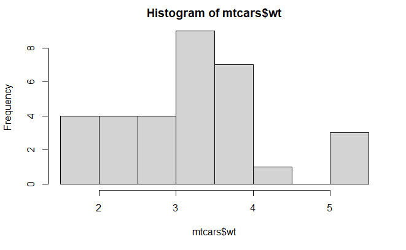

```r
hist(mtcars$wt)
```

```r
?hist
```

Q-Q Plot of wt The Q-Q plot, or quantile-quantile plot, is a graphical tool to help us assess if a set of data plausibly came from some theoretical distribution such as a Normal or exponential. If both sets of quantiles came from the same distribution, we should see the points forming a line that’s roughly straight.

In R, there are two functions to create Q-Q plots: qqnorm and qqplot. qqnorm creates a Normal Q-Q plot. You give it a vector of data and R plots the data in sorted order versus quantiles from a standard Normal distribution. The qqplot function allows you to create a Q-Q plot for any distribution. Unlike the qqnorm function, you have to provide two arguments: the first set of data and the second set of data.

```r
qqnorm(mtcars$wt)
```

[output not shown]

We can draw a line on our Q-Q Plot to help see. First build the plot, then draw the line.

```r
qqnorm(mtcars$wt)
qqline(mtcars$wt)
```

[output not shown]

What correlation do columns have? Rounded to two decimals

```r
round(cor(mtcars),2)
```

[output not shown]

Use corrplot to check the correlation (must be installed first).

```r
corrplot(cor(mtcars), type = "upper", order = "hclust", tl.col = "black", tl.srt = 45)
```

[output not shown]